# Alternative Assessment 2

Irfan Abidin As Salik Bin Noor Riza Al Jeffery (17204593)

5/24/2021

# a) Interprating the confusion matrix

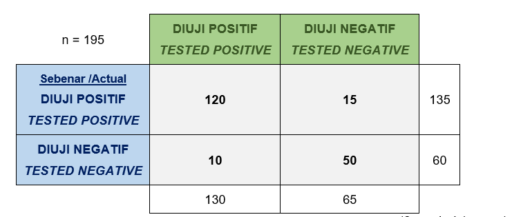

In this example, the model correctly predicted for *Tested Positive* is *120 times* and *incorrectly predicted* it *15 times*. The model correctly predicted for *Tested Negative* is 50 times and *incorrectly predicted* it *10 times*.

### The following can be computed from this confusion matrix:

- The model made **170** correct predictions **(120 + 50)**.
- The model made **25** incorrect predictions **(15 + 10)**.
- There are **195** total scored cases **(120 + 15 + 10 + 50)**.
- The error rate is **25/195** = **0.1282**.
- The overall accuracy rate is **170/195** = **0.8718**.

# b) EDA and Codebook

## EDA

*Description*

- An experiment was conducted to measure and compare the effectiveness of various feed supplements on the growth rate of chickens.

*Format*

- A data frame with *71 observations* on the following *2 variables*.

  *weight* = a numeric variable giving the chick weight.

  *feed* = a factor giving the feed type.

*Details* - Newly hatched chicks were randomly allocated into six groups, and each group was given a different feed supplement. Their weights in grams after six weeks are given along with feed types.

*Dataset of Chicken Weight by Feed Type(first 6 data)*

```
##   weight      feed
## 1    179 horsebean
## 2    160 horsebean
## 3    136 horsebean
## 4    227 horsebean
## 5    217 horsebean
## 6    168 horsebean
```

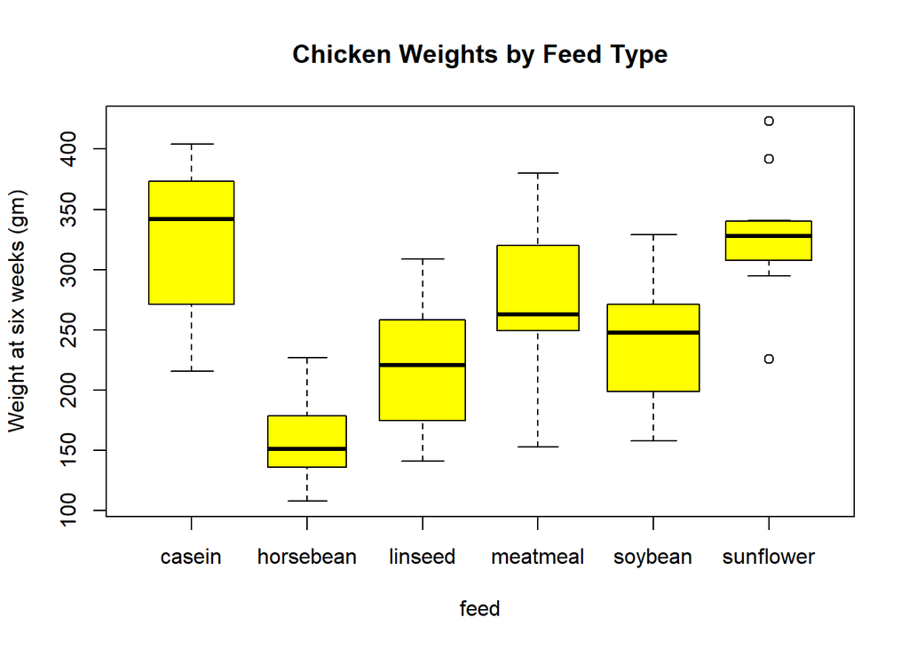

## Codebook

-Categorical Variables

```
##
##    casein horsebean   linseed  meatmeal   soybean sunflower
##        12        10        12        11        14        12
```

- The summary for each feed type.

```
## chickwts$feed: casein
##    Min. 1st Qu.  Median    Mean 3rd Qu.    Max.
##   216.0   277.2   342.0   323.6   370.8   404.0
## ------------------------------------------------------------
## chickwts$feed: horsebean
##    Min. 1st Qu.  Median    Mean 3rd Qu.    Max.
##   108.0   137.0   151.5   160.2   176.2   227.0
## ------------------------------------------------------------
## chickwts$feed: linseed
##    Min. 1st Qu.  Median    Mean 3rd Qu.    Max.
##   141.0   178.0   221.0   218.8   257.8   309.0
## ------------------------------------------------------------
## chickwts$feed: meatmeal
##    Min. 1st Qu.  Median    Mean 3rd Qu.    Max.
##   153.0   249.5   263.0   276.9   320.0   380.0
## ------------------------------------------------------------
## chickwts$feed: soybean
##    Min. 1st Qu.  Median    Mean 3rd Qu.    Max.
##   158.0   206.8   248.0   246.4   270.0   329.0
## ------------------------------------------------------------
## chickwts$feed: sunflower
##    Min. 1st Qu.  Median    Mean 3rd Qu.    Max.
##   226.0   312.8   328.0   328.9   340.2   423.0
```

```
## chickwts$feed: casein
## [1] 323.5833
## ------------------------------------------------------------
## chickwts$feed: horsebean
## [1] 160.2
## ------------------------------------------------------------
## chickwts$feed: linseed
## [1] 218.75
## ------------------------------------------------------------
## chickwts$feed: meatmeal
## [1] 276.9091
## ------------------------------------------------------------
## chickwts$feed: soybean
## [1] 246.4286
## ------------------------------------------------------------
## chickwts$feed: sunflower
## [1] 328.9167
```

# c) Demonstration of dplyr for data manipulation

```
##    Year     Month Palestinians.Killed Israelis.Killed
## 1  2000  DECEMBER                  51               8
## 2  2000  NOVEMBER                 112              22
## 3  2000   OCTOBER                 104              10
## 4  2000 SEPTEMBER                  16               1
## 5  2001  DECEMBER                  67              36
## 6  2001  NOVEMBER                  39              14
## 7  2001   OCTOBER                  89              14
## 8  2001 SEPTEMBER                  59              13
## 9  2001    AUGUST                  37              26
## 10 2001      JULY                  32              10
```

## i) Changing the existing column name.

```r
Palestine1 <- dplyr :: rename(Palestine, "Palestinians_Killed" = Palestinians.Killed, "Israelis_Killed" = Israelis.Killed)
```

## ii) Pick rows based on their values.

```r
dplyr::filter(Palestine1, as.numeric(Palestinians_Killed) > 100)
```

```
##   Year    Month Palestinians_Killed Israelis_Killed
## 1 2000 NOVEMBER                 112              22
## 2 2000  OCTOBER                 104              10
```

- Picked the row with Palestinians_Killed which are more than 100 by using *(dplyr::filter(dataframe, condition))*

## iii) Add new columns to a data frame.

```r
Palestine2 <- dplyr::mutate(Palestine1, Palestinian_Injured = as.numeric(Palestinians_Killed)*2)
```

- Added a new columns named “Palestinian_Injured” and the data are (Palestinians_Killed*2)
- by using _(dplyr::mutate(dataframe, new.variable = choosed.variable*2))_

## iv) Combine data across two or more data frames

```r
dplyr::bind_cols(Palestine2, PalestineCombine)
```

```
##    Year     Month Palestinians_Killed Israelis_Killed Palestinian_Injured
## 1  2000  DECEMBER                  51               8                 102
## 2  2000  NOVEMBER                 112              22                 224
## 3  2000   OCTOBER                 104              10                 208
## 4  2000 SEPTEMBER                  16               1                  32
## 5  2001  DECEMBER                  67              36                 134
## 6  2001  NOVEMBER                  39              14                  78
## 7  2001   OCTOBER                  89              14                 178
## 8  2001 SEPTEMBER                  59              13                 118
## 9  2001    AUGUST                  37              26                  74
## 10 2001      JULY                  32              10                  64
##    Israelis.Injuries
## 1                n/a
## 2                n/a
## 3                n/a
## 4                n/a
## 5                n/a
## 6                n/a
## 7                n/a
## 8                n/a
## 9                n/a
## 10               n/a
```

- Combined 2 set of dataframe (Palestine2) & (PalestineCombine) into one dataframe by using *(dplyr::bind_cols(dataframe1, dataframe2))*